# Intro-Data-Analysis-Pandas-Exercises

```python
# Let's import pandas and some other basic packages we will use
from __future__ import division
%matplotlib inline
import os
import matplotlib.pyplot as plt
import numpy as np
import pandas as pd
```

**Exercise 1:** Create a new dataframe `pop` with population data downloaded from Wikipedia. Make sure to clean the data so it can be used further.

```python
from IPython.display import IFrame
url = 'https://en.wikipedia.org/wiki/List_of_countries_by_population_(United_Nations)'
IFrame(url, width=800, height=400)
pop = pd.read_html(url, encoding='utf-8')[0]
pop.columns = ['Country', 'Continental_Region', 'Statistical_Sub_Region',
               'Population_2018', 'Population_2019', 'Change']

pop
```

|  | Country | Continental_Region | Statistical_Sub_Region | Population_2018 | Population_2019 | Change |
| --- | --- | --- | --- | --- | --- | --- |
| 0 | China[a] | Asia | Eastern Asia | 1427647786 | 1433783686 | +0.43% |
| 1 | India | Asia | Southern Asia | 1352642280 | 1366417754 | +1.02% |
| 2 | United States | Americas | Northern America | 327096265 | 329064917 | +0.60% |
| 3 | Indonesia | Asia | South-eastern Asia | 267670543 | 270625568 | +1.10% |
| 4 | Pakistan | Asia | Southern Asia | 212228286 | 216565318 | +2.04% |
| ... | ... | ... | ... | ... | ... | ... |
| 229 | Falkland Islands (United Kingdom) | Americas | South America | 3234 | 3377 | +4.42% |
| 230 | Niue | Oceania | Polynesia | 1620 | 1615 | −0.31% |
| 231 | Tokelau (New Zealand) | Oceania | Polynesia | 1319 | 1340 | +1.59% |
| 232 | Vatican City[z] | Europe | Southern Europe | 801 | 799 | −0.25% |
| 233 | World | NaN | NaN | 7631091040 | 7713468100 | +1.08% |

234 rows × 6 columns

```python
pop = pop.drop(['Statistical_Sub_Region', 'Change'], axis=1)
pop
```

|  | Country | Continental_Region | Population_2018 | Population_2019 |
| --- | --- | --- | --- | --- |
| 0 | China[a] | Asia | 1427647786 | 1433783686 |
| 1 | India | Asia | 1352642280 | 1366417754 |
| 2 | United States | Americas | 327096265 | 329064917 |
| 3 | Indonesia | Asia | 267670543 | 270625568 |
| 4 | Pakistan | Asia | 212228286 | 216565318 |
| ... | ... | ... | ... | ... |
| 229 | Falkland Islands (United Kingdom) | Americas | 3234 | 3377 |
| 230 | Niue | Oceania | 1620 | 1615 |
| 231 | Tokelau (New Zealand) | Oceania | 1319 | 1340 |
| 232 | Vatican City[z] | Europe | 801 | 799 |
| 233 | World | NaN | 7631091040 | 7713468100 |

234 rows × 4 columns

```python
from IPython.display import IFrame
url = 'https://en.wikipedia.org/wiki/List_of_ISO_3166_country_codes'
IFrame(url, width=800, height=400)
isocodes = pd.read_html(url, encoding='utf-8')[0]
isocodes.columns = ['Country', 'Official_State_Name', 'Sovereignty', 'Alpha_2_Code',
                    'Alpha_3_Code', 'Numeric Code', 'Subdivision_Code', 'Internet_ccTLD']
isocodes
```

|  | Country | Official_State_Name | Sovereignty | Alpha_2_Code | Alpha_3_Code | Numeric Code | Subdivision_Code | Internet_ccTLD |
| --- | --- | --- | --- | --- | --- | --- | --- | --- |
| 0 | Afghanistan | The Islamic Republic of Afghanistan | UN member state | .mw-parser-output .monospaced{font-family:mono... | AFG | 004 | ISO 3166-2:AF | .af |
| 1 | Åland Islands | Åland | Finland | AX | ALA | 248 | ISO 3166-2:AX | .ax |
| 2 | Albania | The Republic of Albania | UN member state | AL | ALB | 008 | ISO 3166-2:AL | .al |
| 3 | Algeria | The People's Democratic Republic of Algeria | UN member state | DZ | DZA | 012 | ISO 3166-2:DZ | .dz |
| 4 | American Samoa | The Territory of American Samoa | United States | AS | ASM | 016 | ISO 3166-2:AS | .as |
| ... | ... | ... | ... | ... | ... | ... | ... | ... |
| 266 | Wallis and Futuna | The Territory of the Wallis and Futuna Islands | France | WF | WLF | 876 | ISO 3166-2:WF | .wf |
| 267 | Western Sahara [ai] | The Sahrawi Arab Democratic Republic | Disputed [aj] | EH | ESH | 732 | ISO 3166-2:EH | [ak] |
| 268 | Yemen | The Republic of Yemen | UN member state | YE | YEM | 887 | ISO 3166-2:YE | .ye |
| 269 | Zambia | The Republic of Zambia | UN member state | ZM | ZMB | 894 | ISO 3166-2:ZM | .zm |
| 270 | Zimbabwe | The Republic of Zimbabwe | UN member state | ZW | ZWE | 716 | ISO 3166-2:ZW | .zw |

271 rows × 8 columns

```python
isocodes = isocodes.drop(['Official_State_Name', 'Sovereignty'], axis=1)
isocodes
```

|  | Country | Alpha_2_Code | Alpha_3_Code | Numeric Code | Subdivision_Code | Internet_ccTLD |
| --- | --- | --- | --- | --- | --- | --- |
| 0 | Afghanistan | .mw-parser-output .monospaced{font-family:mono... | AFG | 004 | ISO 3166-2:AF | .af |
| 1 | Åland Islands | AX | ALA | 248 | ISO 3166-2:AX | .ax |
| 2 | Albania | AL | ALB | 008 | ISO 3166-2:AL | .al |
| 3 | Algeria | DZ | DZA | 012 | ISO 3166-2:DZ | .dz |
| 4 | American Samoa | AS | ASM | 016 | ISO 3166-2:AS | .as |
| ... | ... | ... | ... | ... | ... | ... |
| 266 | Wallis and Futuna | WF | WLF | 876 | ISO 3166-2:WF | .wf |
| 267 | Western Sahara [ai] | EH | ESH | 732 | ISO 3166-2:EH | [ak] |
| 268 | Yemen | YE | YEM | 887 | ISO 3166-2:YE | .ye |
| 269 | Zambia | ZM | ZMB | 894 | ISO 3166-2:ZM | .zm |
| 270 | Zimbabwe | ZW | ZWE | 716 | ISO 3166-2:ZW | .zw |

271 rows × 6 columns

**Exercise 2:** Merge the `isocodes` and `pop` dataframes.

```python
merge = pop.merge(isocodes, left_on='Country', right_on='Country')
merge
```

|  | Country | Continental_Region | Population_2018 | Population_2019 | Alpha_2_Code | Alpha_3_Code | Numeric Code | Subdivision_Code | Internet_ccTLD |
| --- | --- | --- | --- | --- | --- | --- | --- | --- | --- |
| 0 | India | Asia | 1352642280 | 1366417754 | IN | IND | 356 | ISO 3166-2:IN | .in |
| 1 | Indonesia | Asia | 267670543 | 270625568 | ID | IDN | 360 | ISO 3166-2:ID | .id |
| 2 | Pakistan | Asia | 212228286 | 216565318 | PK | PAK | 586 | ISO 3166-2:PK | .pk |
| 3 | Brazil | Americas | 209469323 | 211049527 | BR | BRA | 076 | ISO 3166-2:BR | .br |
| 4 | Nigeria | Africa | 195874683 | 200963599 | NG | NGA | 566 | ISO 3166-2:NG | .ng |
| ... | ... | ... | ... | ... | ... | ... | ... | ... | ... |
| 139 | San Marino | Europe | 33785 | 33860 | SM | SMR | 674 | ISO 3166-2:SM | .sm |
| 140 | Palau | Oceania | 17907 | 18008 | PW | PLW | 585 | ISO 3166-2:PW | .pw |
| 141 | Tuvalu | Oceania | 11508 | 11646 | TV | TUV | 798 | ISO 3166-2:TV | .tv |
| 142 | Nauru | Oceania | 10670 | 10756 | NR | NRU | 520 | ISO 3166-2:NR | .nr |
| 143 | Niue | Oceania | 1620 | 1615 | NU | NIU | 570 | ISO 3166-2:NU | .nu |

144 rows × 9 columns

**Exercise 3:** Merge the dataframes we have created so far to have a unique dataframe that has ISO codes, GDP per capita, and population data.

```python
url = 'https://en.wikipedia.org/wiki/List_of_countries_by_GDP_(PPP)_per_capita'
IFrame(url, width=800, height=400)
gdp_wiki = pd.read_html(url, encoding='utf-8')[1]
gdp_wiki.columns = ['Country/Territory', 'UN_Region', 'IMF', 'Year_IMF', 'World_Bank', 'Year_World_Bank', 'CIA', 'Year_CIA']
gdp_wiki['Country/Territory'] = gdp_wiki['Country/Territory'].str.replace('*', '', regex=True).str.strip()
gdp_wiki.head()
#Palestine had two CIA values
gdp_wiki = gdp_wiki.drop(labels = 139, axis = 0)
gdp_wiki
```

|  | Country/Territory | UN_Region | IMF | Year_IMF | World_Bank | Year_World_Bank | CIA | Year_CIA |
| --- | --- | --- | --- | --- | --- | --- | --- | --- |
| 0 | Luxembourg | Europe | 141587 | 2022 | 134754 | 2021 | 110300 | 2020 |
| 1 | Liechtenstein | Europe | — | — | — | — | 139100 | 2009 |
| 2 | Singapore | Asia | 131426 | 2022 | 116487 | 2021 | 93400 | 2020 |
| 3 | Ireland | Europe | 131034 | 2022 | 106456 | 2021 | 89700 | 2020 |
| 4 | Monaco | Europe | — | — | — | — | 115700 | 2015 |
| ... | ... | ... | ... | ... | ... | ... | ... | ... |
| 225 | DR Congo | Africa | 1328 | 2022 | 1219 | 2021 | 1100 | 2020 |
| 226 | Somalia | Africa | 1322 | 2022 | 1303 | 2021 | 800 | 2020 |
| 227 | Central African Republic | Africa | 1088 | 2022 | 1021 | 2021 | 900 | 2020 |
| 228 | South Sudan | Africa | 934 | 2022 | 1235 | 2015 | 1600 | 2017 |
| 229 | Burundi | Africa | 865 | 2022 | 793 | 2021 | 700 | 2020 |

229 rows × 8 columns

```python
for c in gdp_wiki.columns[2:-1]:
    if gdp_wiki[c].dtype=='O':
        gdp_wiki[c] = pd.to_numeric(gdp_wiki[c].str.replace('—', 'nan'), errors='coerce')
        if c.startswith('year'):
            gdp_wiki[c] = gdp_wiki[c].astype('Int64')
```

```python
gdp_wiki.dtypes
```

```
Country/Territory     object
UN_Region             object
IMF                  float64
Year_IMF             float64
World_Bank           float64
Year_World_Bank      float64
CIA                    int64
Year_CIA              object
dtype: object
```

```python
Big_merge = merge.merge(gdp_wiki, left_on='Country', right_on='Country/Territory')
Big_merge = Big_merge.drop(['Country/Territory', 'UN_Region'], axis=1)
Big_merge
```

|  | Country | Continental_Region | Population_2018 | Population_2019 | Alpha_2_Code | Alpha_3_Code | Numeric Code | Subdivision_Code | Internet_ccTLD | IMF | Year_IMF | World_Bank | Year_World_Bank | CIA | Year_CIA |
| --- | --- | --- | --- | --- | --- | --- | --- | --- | --- | --- | --- | --- | --- | --- | --- |
| 0 | India | Asia | 1352642280 | 1366417754 | IN | IND | 356 | ISO 3166-2:IN | .in | 8293.0 | 2022.0 | 7334.0 | 2021.0 | 6100 | 2020 |
| 1 | Indonesia | Asia | 267670543 | 270625568 | ID | IDN | 360 | ISO 3166-2:ID | .id | 14638.0 | 2022.0 | 12904.0 | 2021.0 | 11400 | 2020 |
| 2 | Pakistan | Asia | 212228286 | 216565318 | PK | PAK | 586 | ISO 3166-2:PK | .pk | 6662.0 | 2022.0 | 5878.0 | 2021.0 | 4600 | 2020 |
| 3 | Brazil | Americas | 209469323 | 211049527 | BR | BRA | 076 | ISO 3166-2:BR | .br | 17684.0 | 2022.0 | 16056.0 | 2021.0 | 14100 | 2020 |
| 4 | Nigeria | Africa | 195874683 | 200963599 | NG | NGA | 566 | ISO 3166-2:NG | .ng | 5884.0 | 2022.0 | 5459.0 | 2021.0 | 4900 | 2020 |
| ... | ... | ... | ... | ... | ... | ... | ... | ... | ... | ... | ... | ... | ... | ... | ... |
| 138 | San Marino | Europe | 33785 | 33860 | SM | SMR | 674 | ISO 3166-2:SM | .sm | 72070.0 | 2022.0 | 59572.0 | 2020.0 | 60800 | 2019 |
| 139 | Palau | Oceania | 17907 | 18008 | PW | PLW | 585 | ISO 3166-2:PW | .pw | 13215.0 | 2022.0 | 16319.0 | 2020.0 | 17600 | 2019 |
| 140 | Tuvalu | Oceania | 11508 | 11646 | TV | TUV | 798 | ISO 3166-2:TV | .tv | 5844.0 | 2022.0 | 5082.0 | 2021.0 | 4400 | 2020 |
| 141 | Nauru | Oceania | 10670 | 10756 | NR | NRU | 520 | ISO 3166-2:NR | .nr | 10834.0 | 2022.0 | 15103.0 | 2021.0 | 13500 | 2019 |
| 142 | Niue | Oceania | 1620 | 1615 | NU | NIU | 570 | ISO 3166-2:NU | .nu | NaN | NaN | NaN | NaN | 5800 | 2003 |

143 rows × 15 columns

**Exercise 4:** Use the `os` package to create folders to export data and figures. Since you will be using the names of these folders a lot, save their names in variables called `path`, `pathout`, and `pathgraphs`, where `path = './data/'`, `pathout = './data/'`, and `pathgraphs = './graphs/'`

```python
directory = 'pathout'
parent_dir ='/Users/ikertrevino/Desktop/Economic Growth/notebooks/Intro-Data-Analysis-Pandas-Exercises'
path = os.path.join(parent_dir, directory)
os.mkdir(path)
print("Directory '% s' created" % directory)
```

```
Directory 'pathout' created
```

```python
directory_2 = 'pathgraphs'
parent_dic ='/Users/ikertrevino/Desktop/Economic Growth/notebooks/Intro-Data-Analysis-Pandas-Exercises'
path_2 = os.path.join(parent_dir, directory_2)
os.mkdir(path_2)
print("Directory '% s' created" % directory_2)
```

```
Directory 'pathgraphs' created
```

**Exercise 5:** Save the dataframe created in Exercise 3 as a **CSV, XLSX, and Stata** file into the `pathout` folder. Use a variable called `filename = 'Wiki_Data'` so you can use similar code to save all file types. Notice only the filetype will change.

```python
file_name = 'Wiki_Data.xlsx'
Big_merge.to_excel(file_name)
print('DataFrame is written to Excel File successfully.')
import shutil
source_og = '/Users/ikertrevino/Desktop/Economic Growth/notebooks/Intro-Data-Analysis-Pandas-Exercises/pathout'
source_new = '/Users/ikertrevino/Desktop/Economic Growth/notebooks/Intro-Data-Analysis-Pandas-Exercises/pathout'
shutil.move(source_og, source_new)
```

```
DataFrame is written to Excel File successfully.
```

```python
file_name2 = 'Wiki_Data.csv'
Big_merge.to_csv(file_name2)
print('DataFrame is written to CSV File successfully.')
source_og = '/Users/ikertrevino/Desktop/Economic Growth/notebooks/Intro-Data-Analysis-Pandas-Exercises/pathout'
soruce_new ='/Users/ikertrevino/Desktop/Economic Growth/notebooks/Intro-Data-Analysis-Pandas-Exercises/pathout'
shutil.move(source_og, source_new)
```

```
DataFrame is written to CSV File successfully.
```

```python
file_name3 = 'Wiki_Data.stata'
Big_merge.to_stata(file_name3)
print('DataFrame is written to Stata File successfully.')
source_og = '/Users/ikertrevino/Desktop/Economic Growth/notebooks/Intro-Data-Analysis-Pandas-Exercises/pathout'
source_new ='/Users/ikertrevino/Desktop/Economic Growth/notebooks/Intro-Data-Analysis-Pandas-Exercises/pathout'
source_og = shutil.move(source_og, source_new)
```

```
DataFrame is written to Stata File successfully.
```

[output not shown]

**Exercise 6:** Create plots showing the relation between GDP per capita and Population. Create all 4 types of possible regression plots and save them as **PNG, PDF, and JPG** files. Make sure to save them in the folder you created for **graphs**

```python
loy = np.log(Big_merge['IMF'])
print(loy)
Big_merge['Log GDP per Capita'] = loy

lox = np.log(Big_merge['Population_2019'])
print(lox)
Big_merge['Log Population_2019'] = lox
```

```
0       9.023167
1       9.591376
2       8.804175
3       9.780416
4       8.679992
         ...
138    11.185393
139     9.489108
140     8.673171
141     9.290445
142          NaN
Name: IMF, Length: 143, dtype: float64
0      21.035458
1      19.416247
2      19.193403
3      19.167603
4      19.118634
         ...
138    10.429990
139     9.798571
140     9.362718
141     9.283219
142     7.387090
Name: Population_2019, Length: 143, dtype: float64
```

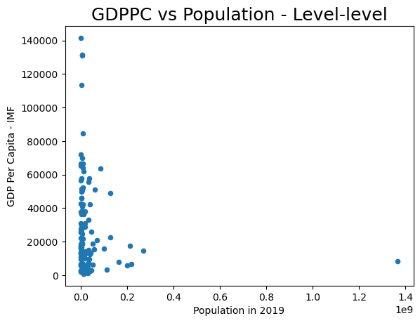

```python
f1 = Big_merge.plot.scatter(x='Population_2019', y='IMF')
plt.title("GDPPC vs Population - Level-level", fontsize = 18)
plt.xlabel("Population in 2019")
plt.ylabel("GDP Per Capita - IMF")

plt.savefig('/Users/ikertrevino/Desktop/Economic Growth/notebooks/Intro-Data-Analysis-Pandas-Exercises/pathgraphs/Level-level.png')
plt.savefig('/Users/ikertrevino/Desktop/Economic Growth/notebooks/Intro-Data-Analysis-Pandas-Exercises/pathgraphs/Level-level.pdf')
plt.savefig('/Users/ikertrevino/Desktop/Economic Growth/notebooks/Intro-Data-Analysis-Pandas-Exercises/pathgraphs/Level-level.jpg')
```

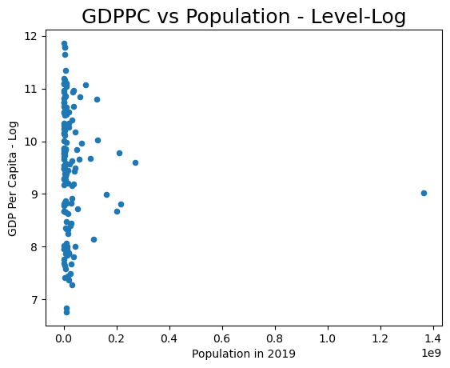

```python
f2 = Big_merge.plot.scatter(x='Population_2019', y='Log GDP per Capita')
plt.title("GDPPC vs Population - Level-Log", fontsize = 18)
plt.xlabel("Population in 2019")
plt.ylabel("GDP Per Capita - Log")

plt.savefig('/Users/ikertrevino/Desktop/Economic Growth/notebooks/Intro-Data-Analysis-Pandas-Exercises/pathgraphs/Level-Log.png')
plt.savefig('/Users/ikertrevino/Desktop/Economic Growth/notebooks/Intro-Data-Analysis-Pandas-Exercises/pathgraphs/Level-Log.pdf')
plt.savefig('/Users/ikertrevino/Desktop/Economic Growth/notebooks/Intro-Data-Analysis-Pandas-Exercises/pathgraphs/Level-Log.jpg')
```

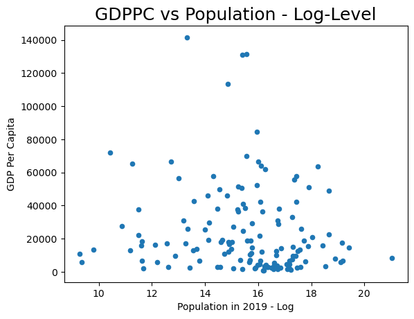

```python
f3 = Big_merge.plot.scatter(x='Log Population_2019', y='IMF')
plt.title("GDPPC vs Population - Log-Level", fontsize = 18)
plt.xlabel("Population in 2019 - Log")
plt.ylabel("GDP Per Capita")

plt.savefig('/Users/ikertrevino/Desktop/Economic Growth/notebooks/Intro-Data-Analysis-Pandas-Exercises/pathgraphs/Log-Level.png')
plt.savefig('/Users/ikertrevino/Desktop/Economic Growth/notebooks/Intro-Data-Analysis-Pandas-Exercises/pathgraphs/Log-Level.pdf')
plt.savefig('/Users/ikertrevino/Desktop/Economic Growth/notebooks/Intro-Data-Analysis-Pandas-Exercises/pathgraphs/Log-Level.jpg')
```

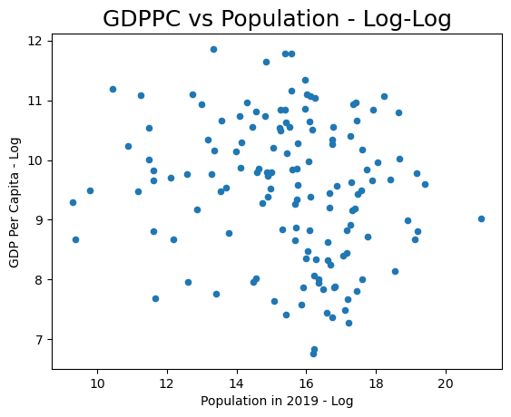

```python
f4 = Big_merge.plot.scatter(x='Log Population_2019', y='Log GDP per Capita')
plt.title("GDPPC vs Population - Log-Log", fontsize = 18)
plt.xlabel("Population in 2019 - Log")
plt.ylabel("GDP Per Capita - Log")

plt.savefig('/Users/ikertrevino/Desktop/Economic Growth/notebooks/Intro-Data-Analysis-Pandas-Exercises/pathgraphs/Log-Log.png')
plt.savefig('/Users/ikertrevino/Desktop/Economic Growth/notebooks/Intro-Data-Analysis-Pandas-Exercises/pathgraphs/Log-Log.pdf')
plt.savefig('/Users/ikertrevino/Desktop/Economic Growth/notebooks/Intro-Data-Analysis-Pandas-Exercises/pathgraphs/Log-Log.jpg')
```

**Exercise 8:** Using the notebook create slides for presenting your work and results. Once you have your slides, create a new public repo, publish it, and make sure to create a READ.ME file that show links to the notebook, html, and slides. Also, create the gh-pages branch to have a working slides webpage.

```python
See Git Hub
```

[output not shown]